# DevMasters Hands-On Workshop

## Outline:

### - What is the DevMasters?

### - Exploratory Data Analysis in Python

### - Introduction to Machine Learning

### - Predicting Height from a Given Weight with Simple Linear Regression

### - Join a DevMasters Program

## What is the DevMasters?

The DevMasters is an artificial intelligence company that is based in Irvine and El Segundo. The company consults with clients to bring the power of AI and data analytics to their needs and preferences. Particularly specializing in recommender systems and natural language processing, many companies and firms trust DevMasters to get the job done. DevMasters also provides professional bootcamps to democratize Data Science education and help people become professional data scientists in the industry.

```python
from IPython.core.display import display, HTML, Markdown, Image
from IPython.display import IFrame

display(IFrame(src='https://www.thedevmasters.com', width=800, height=400))
```

[interactive chart not shown]

## What is Data Science?

Data Science is an interdisciplinary field about processes and systems to extract knowledge or insights from data in various forms, either structured or unstructured, which is a continuation of some of the data analysis fields such as statistics, data mining, and predictive analytics.

Data science utilizes data preparation, statistics, predictive modeling and machine learning to investigate problems in various domains such as agriculture, marketing optimization, fraud detection, risk management, marketing analytics, public policy, etc. It emphasizes the use of general methods such as machine learning that apply without changes to multiple domains. Machine learning is the result of good data science.

### What Do Data Scientists Do?

Data scientists use their data and analytical ability to find and interpret rich data sources; manage large amounts of data despite hardware, software, and bandwidth constraints; merge data sources; ensure consistency of datasets; create visualizations to aid in understanding data; build mathematical models using the data; and present and communicate the data insights/findings. They are often expected to produce answers in days rather than months, work by exploratory analysis and rapid iteration, and to get/present results with dashboards (displays of current values) rather than papers/reports, as statisticians normally do.

### What Skills Are Needed?

The data scientist should have a good math/statistics background. Also a data scientist’s most basic, universal skill is the ability to write code.

A data scientist must be able to tell a story to stakeholders based on the data that they arrived at as a result of experimenting and testing. This data is a result of the code they wrote. Thus, they created their own programming tools for this experimenting and testing. So they are definitely scientists. And they should be extroverts too since they are presenting their data to others.

A data scientist needs to be able to code in Java, C (C, C++, C#), or likewise language. A person who can code these languages can learn Python pretty quickly. Python is the most popular data science programming tool since it has libraries supporting math, statistical analysis, and plotting. It’s used by mathematicians and analysts to prototype new functionality. R is a good programming tool for graphing and plotting.

Some of the best and brightest data scientists are PhDs in esoteric fields like ecology and systems biology. George Roumeliotis, the head of a data science team at Intuit in Silicon Valley, holds a doctorate in astrophysics. A little less surprisingly, many of the data scientists working in the business today were formally trained in computer science, math, or economics. They can emerge from any field that has a strong data and computational focus.

To sum up the skills:

1. Ability to Write Code in Java, C type languages, Python. R is a programming option too.
2. Degrees in a scientific field, computer science, math, economics or related.
3. Good with math and statistics.
4. A gregarious person with good communication skills.

Content from https://blog.thedevmasters.com/4-essential-skills-to-become-data-scientist

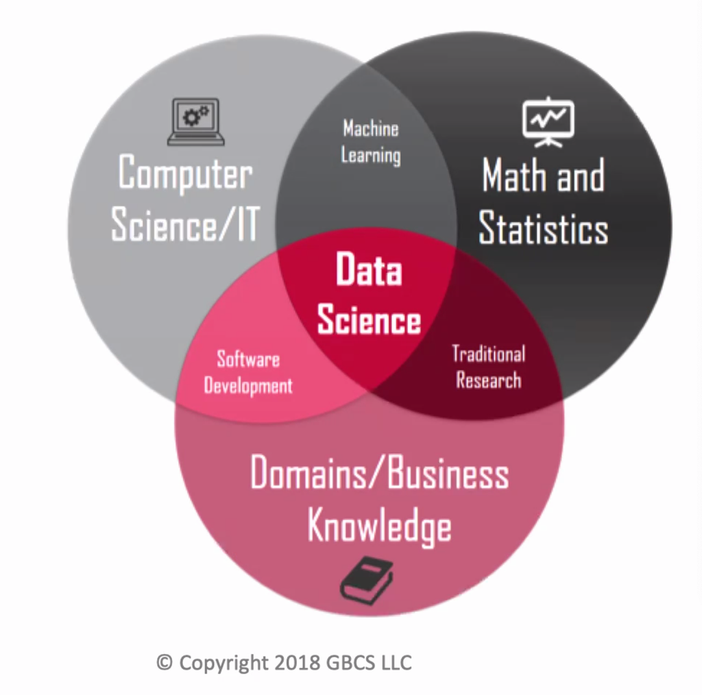

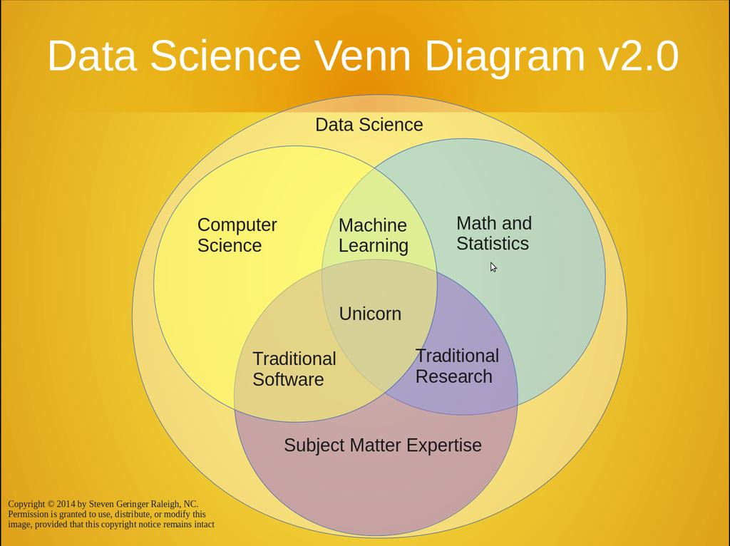

```python
display(Image("https://i.imgur.com/8U8sQKD.png", height=500, width=800))
display(Image("https://1.bp.blogspot.com/-ju4m6PBOrgo/V-E5qz99SaI/AAAAAAAAMF0/gle0zsZz_nIBEMVg0EdZHoGJhjlnBzv1gCLcB/s1600/moz-screenshot-3-729576.png", height=500, width=800))
```

## What is CRISP-DM?

The Cross Industry Standard Process for Data Mining (CRISP-DM) was a concept developed 20 years ago now. The model splits a data mining project into six phases and it allows for needing to go back and forth between different stages. I’d personally stick a few more backwards arrows but it’s generally fine. The CRISP-DM model applies equally well to a data science project.

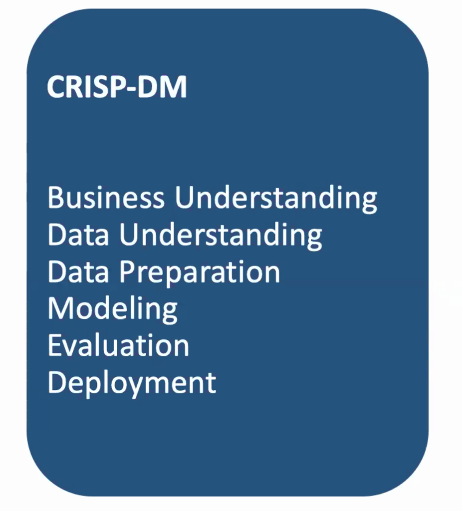

```python
display(Image("https://i.imgur.com/esXfOy3.png", height=500, width=800))
```

The Process in Detail:

- Business Understanding -- Understanding the business goal -- Situation assessment -- Translating the business goal in a data mining objective -- Development of a project plan
- Data understanding -- Considering data requirements -- Initial data collection, exploration, and quality assessment
- Data preparation -- Selection of required data -- Data acquisition -- Data integration and formatting -- Data cleaning -- Data tranaformation and enrichment
- Modeling -- Selection of appropriate modeling technique -- Splitting of the dataset into training and testing subsets for evaluation purposes -- Development and examination of alternative modeling algorithms and parameter settings -- Fine tuning of the model settings according to an initial assessment of the model’s performance
- Model Evaluation -- Evaluation of the model in the context of the business success criteria -- Model approval
- Deployment -- Create a report of findings -- Planning and development of the deployment procedure -- Deployment of the model -- Distribution of the model results and integration in the organisation’s operational system -- Development of a maintenance / update plan -- Review of the project -- Planning the next steps

Content from https://itsalocke.com/blog/crisp-dm-and-why-you-should-know-about-it/

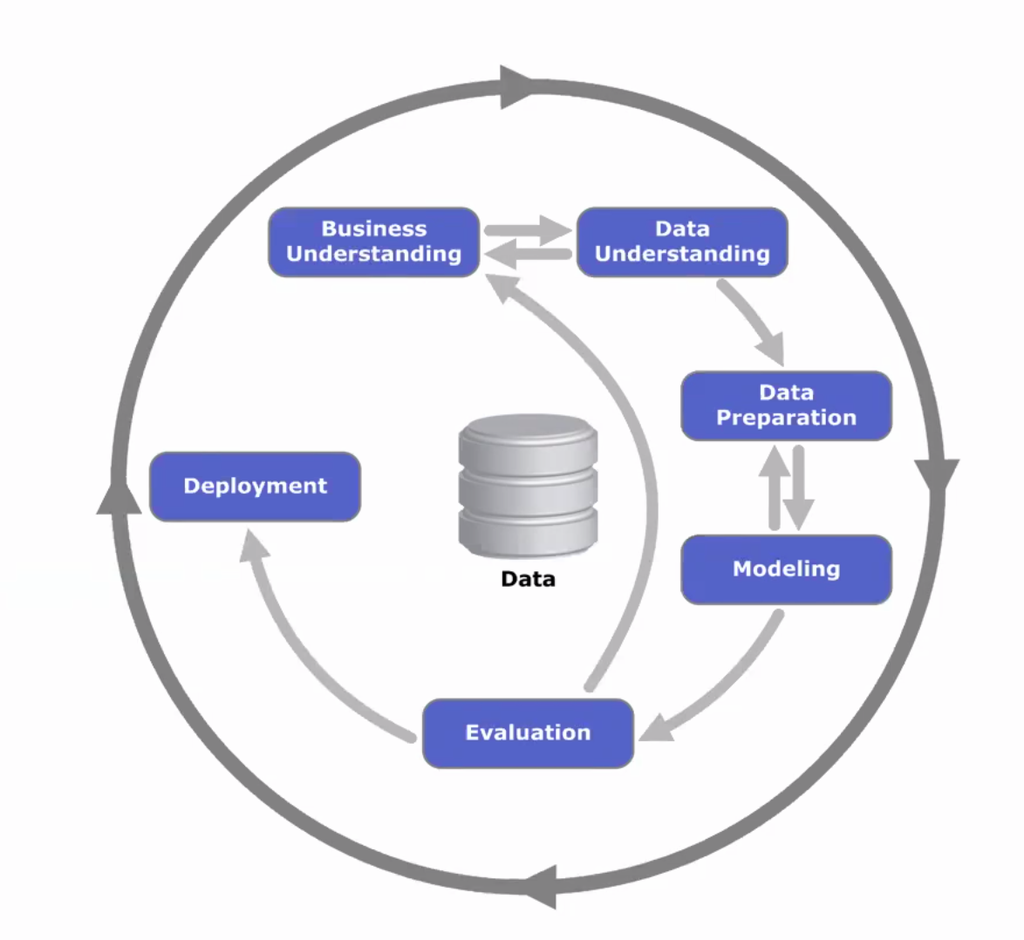

```python
display(Image("https://i.imgur.com/l5f8frh.png", height=500, width=800))
```

## Exploratory Data Analysis in Python

The data science project that will be gone over today is one where you, the data scientist, will want to help your business come up with a model that can make personalized wearables in the form of t-shirts. You are given a dataset which will help you to understand the data you have to work with in order to build a predictive model to keep your company with great progress.

$$ \text{dataset} \space \rightarrow \space \text{heightweight.csv} $$

A little note about the file format:

.csv is the file extension for a data file known as a comma-separated value file

What this means is that the columns and rows are all separated by commas from the beginning all the way to the end of your dataset. We'll learn how Python makes use of a data analysis library called pandas which will transform this comma separated format into a format that we can read with more ease to learn from the data.

```python
display(Markdown("# Viewing the inside of the csv data file"))
```

Viewing the inside of the csv data file

```python
cat heightweight.csv
```

[output not shown]

### Introduction to Pandas

```python
# Import the pandas library

import pandas as pd

# Let's turn the data from a csv file into a pandas DataFrame object

df = pd.read_csv("heightweight.csv")

# Let's view the first 5 rows of the data frame with the head() method in pandas

df.head()

display(Markdown("### Meaning of shape"))
display(HTML("<br />"))
display(Markdown(" Shape tells us how many rows there are in the dataframe and how many columns there are."))
display(HTML("<br />"))

# Getting the shape
df.shape
display(Markdown(f" ### The shape of our data's data frame object is {df.shape[0]} rows and {df.shape[1]} columns"))
```

Meaning of shape

Shape tells us how many rows there are in the dataframe and how many columns there are.

The shape of our data's data frame object is 237 rows and 5 columns

### Learning About Your Data with Pandas

```python
# Get information about the data types of the column values in your dataset

df.info()
```

```
<class 'pandas.core.frame.DataFrame'>
RangeIndex: 237 entries, 0 to 236
Data columns (total 5 columns):
gender      237 non-null object
ageYear     237 non-null float64
ageMonth    237 non-null int64
HeightIn    237 non-null float64
WeightLB    237 non-null float64
dtypes: float64(3), int64(1), object(1)
memory usage: 9.3+ KB
```

```python
# Get some summary statistics about your data using .describe()

df.describe()
```

|  | ageYear | ageMonth | HeightIn | WeightLB |
| --- | --- | --- | --- | --- |
| count | 237.000000 | 237.000000 | 237.000000 | 237.000000 |
| mean | 13.702532 | 164.430380 | 61.364557 | 101.308017 |
| std | 1.535481 | 18.425767 | 3.945402 | 19.440698 |
| min | 11.583330 | 139.000000 | 50.500000 | 50.500000 |
| 25% | 12.333330 | 148.000000 | 58.800000 | 85.000000 |
| 50% | 13.583330 | 163.000000 | 61.500000 | 101.000000 |
| 75% | 14.833330 | 178.000000 | 64.300000 | 112.000000 |
| max | 20.833330 | 250.000000 | 72.000000 | 171.500000 |

### Using Visualization to Add to Your EDA

Rather than just relying solely on the data analysis capabilities with pandas, we can also visualize what's going on in the data by generating some plots with visualization libraries. Very popular visualization libraries in Python include:

- Matplotlib
- Seaborn
- Plotly
- Bokeh
- graphviz

For this workshop, we'll mainly use visualization offered by pandas through the help of matplotlib and one really cool plot with seaborn.

```
['gender' 'ageYear' 'ageMonth' 'HeightIn' 'WeightLB']
```

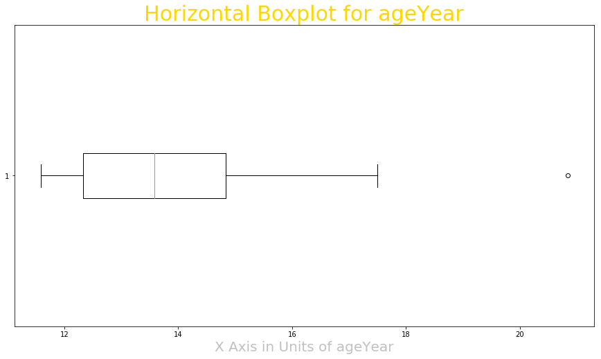

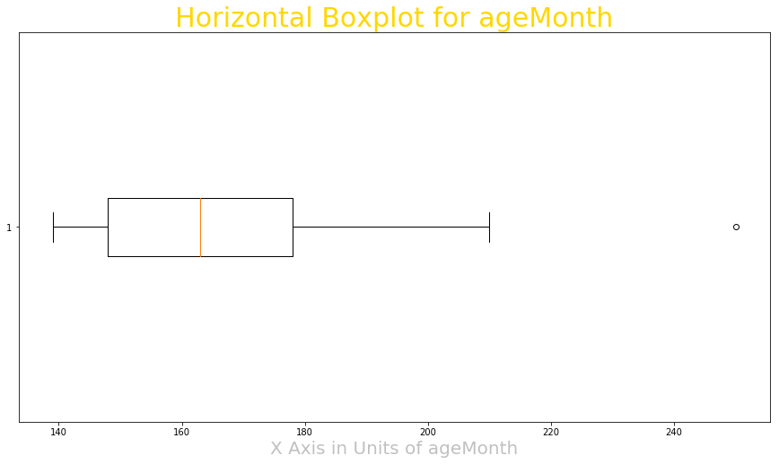

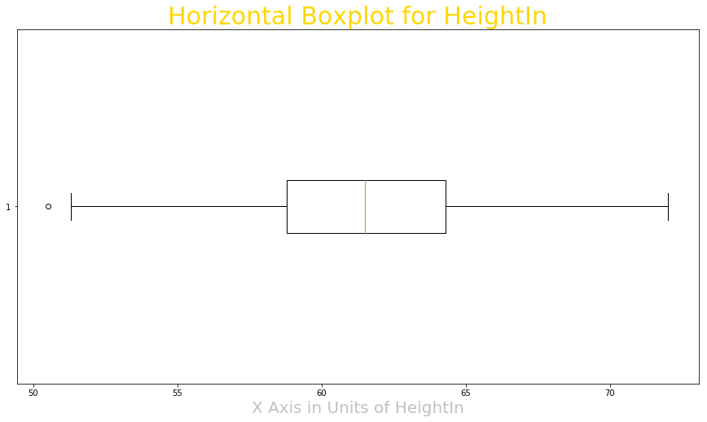

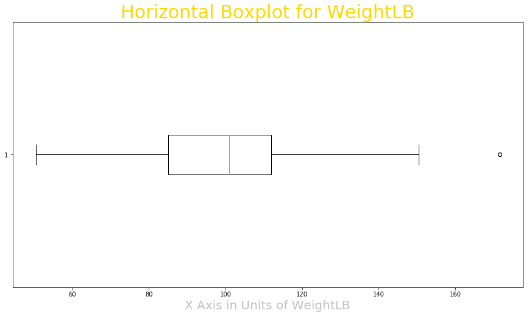

```python
# Importing matplotlib
import matplotlib.pyplot as plt
# We are using the pyplot API inside of the matplotlib package for making graphs
%matplotlib inline
# The reason we use this is so the graphs show up in the notebook

# Getting all the column names from the dataframe
print(df.columns.values)

# Using a for loop to get each column from the list of columns

for column in df.columns.values[1:]:
    # Generating a horizontal boxplot for each column except gender
    # Setting the plot size to be nice and big
    plt.figure(figsize=(15,8))
    # Setting the title for each boxplot
    plt.title(f"Horizontal Boxplot for {column}", size="30", color="gold")
    # Setting the text for the x axis
    plt.xlabel(f"X Axis in Units of {column}", size="20", color='silver')
    plt.boxplot(df[column], vert=False)
```

From these boxplots, we can see a visual representation of some of the variables with their descriptive statistics. The next thing we'll do is display histograms of the two columns we care about the most for our task: Height (in inches) and Weight (in pounds).

```python
display(Markdown("## To generate the histograms, we can simply use pandas .hist() method for the columns we want to visualize."))
```

To generate the histograms, we can simply use pandas .hist() method for the columns we want to visualize.

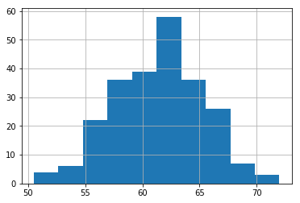

```python
# Setting up histogram for Height and Weight columns
df['HeightIn'].hist()
```

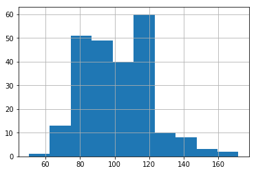

```python
df['WeightLB'].hist()
```

```
Text(0,0.5,'Frequency')
```

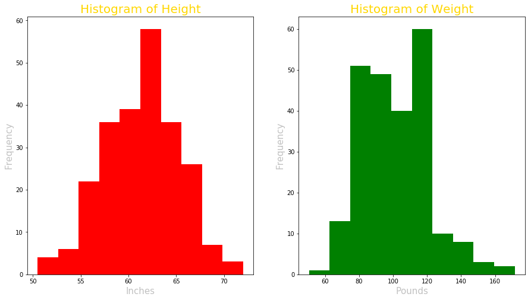

```python
# Getting the histograms side by side with matplotlib subplots function

fig, ax = plt.subplots(1,2, figsize=(15,8))
# Height Histogram
ax[0].hist(df['HeightIn'], color='red')
ax[0].set_title("Histogram of Height", size="20", color="gold")
ax[0].set_xlabel("Inches", size="15", color="silver")
ax[0].set_ylabel("Frequency", size="15", color="silver")
# Weight Histogram
ax[1].hist(df['WeightLB'], color='green')
ax[1].set_title("Histogram of Weight", size="20", color="gold")
ax[1].set_xlabel("Pounds", size="15", color="silver")
ax[1].set_ylabel("Frequency", size="15", color="silver")
```

Why do we want to visualize the histograms of these two columns? The main reason is because we want to see how their distribution is. If they follow what we call a normal distribution, then when we do some machine learning analysis with these columns, the results will have less bias so the model won't necessarily be corrupted.

```python
display(Markdown("# Generating the Normal Distribution"))
```

Generating the Normal Distribution

Let's generate the normal distribution to get a better understanding of what it looks like and what we want the distribution of our columns to be as close to.

In order to do this though, let's get a little more mathematical understanding of what the normal distribution looks like.

In statistics, we often look at functions known as probability density functions (PDFs). When we look at understanding confidence intervals, we tend to rely on these PDFs that can generate normality within the data. For our case, we'll generate a perfect normal curve by studying its PDF.

The PDF for a normal distribution function for any mean or standard deviation is:

$$ f(x \space | \space \mu , \sigma ^2) = \frac{1}{\sqrt{2 \pi \sigma ^2}}e^{\frac{-(x - \mu)^2}{\sigma^2}} $$

Don't get scared by this crazy-looking mathematical equation. In a normal (pun-intended) statistics class, we can actually simplify this equation a great deal.

Before we do that, we need to familiarize ourselves with two mathematical symbols and what they refer to:

$$ \mu = \text{The mean of our data} $$ $$ \sigma^2 = \text{The variance of our data} $$

Let's say we set our mean to be 0 and our variance to be 1. We can now simplify our equation to look like this:

$$ f(x) = \frac{1}{\sqrt{2 \pi}}e^{-(x^2)} $$

We'll make this simple normal probability distribution function in Python using a matrix and numerical computing library called Numpy.

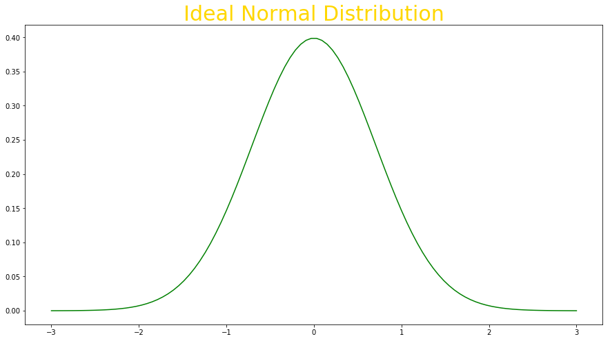

```python
# importing numpy
import numpy as np

# Generating a numpy array which will be used to plot the PDF 3 standard deviations from the mean of 0

x = np.linspace(-3,3, num=100)

# Writing out the normal PDF function with mean = 0 and variance = 1

def normalPDF(x):
    constant = 1/(np.sqrt(2*np.pi))
    return constant * np.exp(-x**2)

# Plotting the normal PDF with matplotlib plot()
plt.figure(figsize=(15,8))
plt.title("Ideal Normal Distribution", size="30", color="gold")
plt.plot(x, normalPDF(x), 'g-')
```

Now let's see what the normal probability distributions look like by fitting to the mean and variance of our two columns. To do this, we'll use a scientific computing library in Python called scipy which has an API for statistics called stats which can numerically compute the normal PDF in a few lines of Python code.

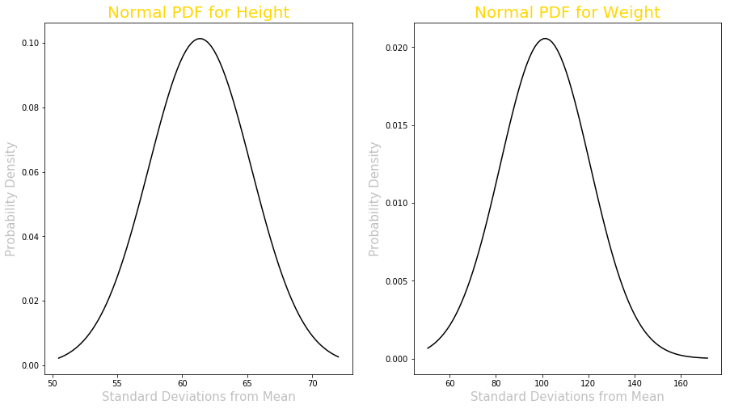

```python
# importing scipy.stats
from scipy import stats

# Getting the normal PDF for the Height column
x_height = np.linspace(np.min(df['HeightIn']), np.max(df['HeightIn']), num=100)
y_height = stats.norm.pdf(x_height, np.mean(df['HeightIn']), np.std(df['HeightIn']))

# Getting the normal PDF for the Weight column
x_weight = np.linspace(np.min(df['WeightLB']), np.max(df['WeightLB']), num=100)
y_weight = stats.norm.pdf(x_weight, np.mean(df['WeightLB']), np.std(df['WeightLB']))

# Plotting the normal PDFs side by side

fig, ax = plt.subplots(1,2, figsize=(15,8))
# Height Normal PDF
ax[0].set_title("Normal PDF for Height", size="20", color="gold")
ax[0].set_xlabel("Standard Deviations from Mean", size="15", color="silver")
ax[0].set_ylabel("Probability Density", size="15", color="silver")
ax[0].plot(x_height, y_height, 'k-')

# Weight Normal PDF
ax[1].set_title("Normal PDF for Weight", size="20", color="gold")
ax[1].set_xlabel("Standard Deviations from Mean", size="15", color="silver")
ax[1].set_ylabel("Probability Density", size="15", color="silver")
ax[1].plot(x_weight, y_weight, 'k-')
```

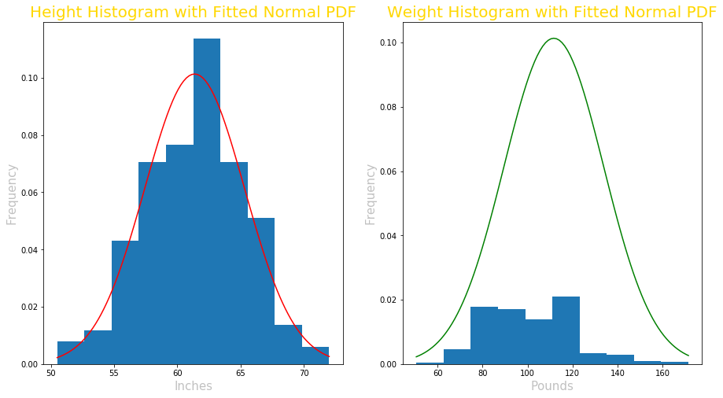

```python
fig, ax = plt.subplots(1,2, figsize=(15,8))
# Height Histogram with Normal Curve Fit
ax[0].set_title("Height Histogram with Fitted Normal PDF", size="20", color="gold")
ax[0].set_xlabel("Inches", size="15", color="silver")
ax[0].set_ylabel("Frequency", size="15", color="silver")
ax[0].plot(x_height, y_height, 'r-')
ax[0].hist(df['HeightIn'], density=True)

# Weight Histogram with Normal Curve Fit
ax[1].set_title("Weight Histogram with Fitted Normal PDF", size="20", color="gold")
ax[1].set_xlabel("Pounds", size="15", color="silver")
ax[1].set_ylabel("Frequency", size="15", color="silver")
ax[1].plot(x_weight, y_height, 'g-')
ax[1].hist(df['WeightLB'], density=True)
```

### A Little EDA with the 'gender' column

```python
# Getting the first 5 rows of the gender columm
df['gender'].head()

# Seeing how many genders there are
df['gender'].nunique()

# Labels of gender
df['gender'].unique()

# Seeing the number of records for each gender in the dataset
df['gender'].value_counts()
```

```
m    126
f    111
Name: gender, dtype: int64
```

### Getting Median, Mode and Range

```python
# Median
print(df.HeightIn.median())

# Mode
print(df.HeightIn.mode())

# Range

print((np.max(df['HeightIn']) - np.min(df['HeightIn'])))
```

```
61.5
0    61.5
dtype: float64
21.5
```

### The Relationship Between Height and Weight

In order to see the relationship between height and weight, we'll use a scatterplot with matplotlib.

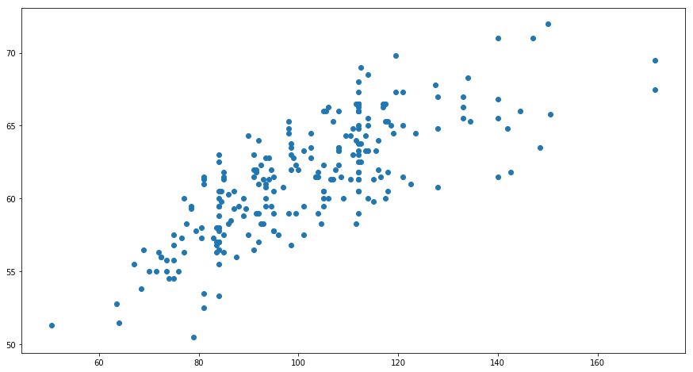

```python
plt.figure(figsize=(15,8))
plt.scatter(df.WeightLB, df.HeightIn)
```

A scatterplot can help us observe the kind of relationship there is between two variables and in this case, we can see that there is some kind of linear, positive relationship between Height and Weight. We do not yet have the exact correlation between the two variables, but we can still plot the line of best fit using the regplot from the seaborn data visualization package.

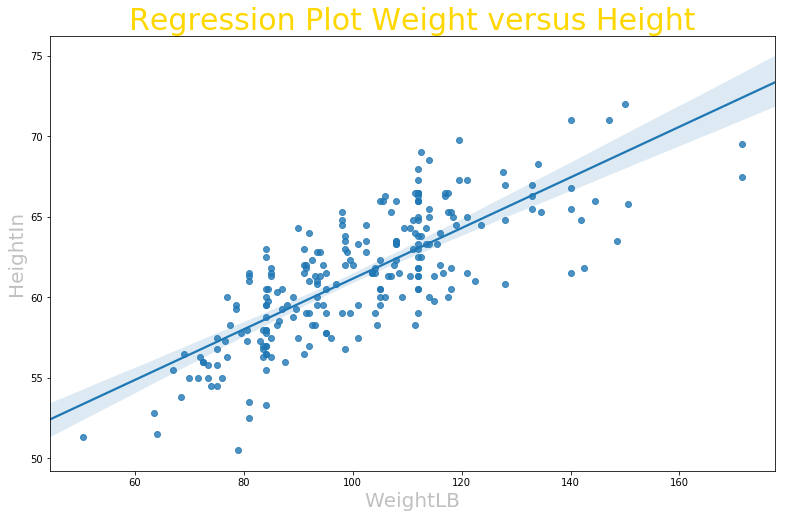

```python
# importing seaborn
import seaborn as sns

# Getting the line of best fit in the scatter plot

plt.figure(figsize=(13,8))
plt.tight_layout()
plt.title("Regression Plot Weight versus Height", size="30", color="gold")
plt.xlabel('WeightLB', size="20", color="silver")
plt.ylabel('HeightIn', size="20", color="silver")
sns.regplot(x=df.WeightLB, y=df.HeightIn, data=df)
```

## Introduction to Machine Learning

Machine Learning in one sentence:

By being shown relevant examples from past data, machines can develop a powerful intuition about new data.

The chief decision scientist of Google says that machine learning is being able to:

"Explain with examples, not instructions." - Cassie Kozyrkov

Two Kinds of Machine Learning

1. Supervised Learning
2. Unsupervised Learning

### Supervised Learning

Supervised learning is typically done in the context of classification, when we want to map input to output labels, or regression, when we want to map input to a continuous output. Common algorithms in supervised learning include logistic regression, naive bayes, support vector machines, artificial neural networks, and random forests. In both regression and classification, the goal is to find specific relationships or structure in the input data that allow us to effectively produce correct output data. Note that “correct” output is determined entirely from the training data, so while we do have a ground truth that our model will assume is true, it is not to say that data labels are always correct in real-world situations. Noisy, or incorrect, data labels will clearly reduce the effectiveness of your model.

When conducting supervised learning, the main considerations are model complexity, and the bias-variance tradeoff. Note that both of these are interrelated.

Model complexity refers to the complexity of the function you are attempting to learn — similar to the degree of a polynomial. The proper level of model complexity is generally determined by the nature of your training data. If you have a small amount of data, or if your data is not uniformly spread throughout different possible scenarios, you should opt for a low-complexity model. This is because a high-complexity model will overfit if used on a small number of data points. Overfitting refers to learning a function that fits your training data very well, but does not generalize to other data points — in other words, you are strictly learning to produce your training data without learning the actual trend or structure in the data that leads to this output. Imagine trying to fit a curve between 2 points. In theory, you can use a function of any degree, but in practice, you would parsimoniously add complexity, and go with a linear function.

The bias-variance tradeoff also relates to model generalization. In any model, there is a balance between bias, which is the constant error term, and variance, which is the amount by which the error may vary between different training sets. So, high bias and low variance would be a model that is consistently wrong 20% of the time, whereas a low bias and high variance model would be a model that can be wrong anywhere from 5%-50% of the time, depending on the data used to train it. Note that bias and variance typically move in opposite directions of each other; increasing bias will usually lead to lower variance, and vice versa. When making your model, your specific problem and the nature of your data should allow you to make an informed decision on where to fall on the bias-variance spectrum. Generally, increasing bias (and decreasing variance) results in models with relatively guaranteed baseline levels of performance, which may be critical in certain tasks. Additionally, in order to produce models that generalize well, the variance of your model should scale with the size and complexity of your training data — small, simple data-sets should usually be learned with low-variance models, and large, complex data-sets will often require higher-variance models to fully learn the structure of the data.

### Unsupervised Learning

The most common tasks within unsupervised learning are clustering, representation learning, and density estimation. In all of these cases, we wish to learn the inherent structure of our data without using explicitly-provided labels. Some common algorithms include k-means clustering, principal component analysis, and autoencoders. Since no labels are provided, there is no specific way to compare model performance in most unsupervised learning methods.

Two common use-cases for unsupervised learning are exploratory analysis and dimensionality reduction.

Unsupervised learning is very useful in exploratory analysis because it can automatically identify structure in data. For example, if an analyst were trying to segment consumers, unsupervised clustering methods would be a great starting point for their analysis. In situations where it is either impossible or impractical for a human to propose trends in the data, unsupervised learning can provide initial insights that can then be used to test individual hypotheses.

Dimensionality reduction, which refers to the methods used to represent data using less columns or features, can be accomplished through unsupervised methods. In representation learning, we wish to learn relationships between individual features, allowing us to represent our data using the latent features that interrelate our initial features. This sparse latent structure is often represented using far fewer features than we started with, so it can make further data processing much less intensive, and can eliminate redundant features.

Content from:

1. https://hackernoon.com/the-simplest-explanation-of-machine-learning-youll-ever-read-bebc0700047c
2. https://towardsdatascience.com/supervised-vs-unsupervised-learning-14f68e32ea8d

```python
from IPython.display import YouTubeVideo
display(Markdown("# Watch Machine Learning - A New Programming Paradigm"))
display(YouTubeVideo("KRvjGYIdJrg", height=500, width=800))
```

Watch Machine Learning - A New Programming Paradigm

[video not shown]

## Predicting Height from a Given Weight with Simple Linear Regression

### Linear Regression Equation

In Simple Algebraic Form:

$$ \hat{y} = mx + b $$

In the equation above, $ \hat{y} $ is the predicted output, m is the slope, x is in our input variable, and b is the intercept of the regression line.

To see linear regression in a more theoretical form:

$$ \hat{y} = \beta_1 x_i + \beta_0 $$

```python
# Using linregress from scipy.stats

regResult = stats.linregress(df.WeightLB, df.HeightIn)
# Returns a object called LinregressResult which has attributes
print(regResult)

# Getting the slope and intercept and r^2 values

print(f"Slope is : {regResult.slope} \n Intercept is {regResult.intercept} \n r^square is {regResult.rvalue**2}")

# Building the predictive model

def predict_height():
    weight = float(input("Enter a weight value: "))
    model_height = regResult.slope*weight + regResult.intercept
    pred_height = np.float(model_height / 12)
    return pred_height

predict_height();


# Validation

# Saving all the actual HeightIn values for records where WeightLB is equal to 105.
test_values = list(df[(df['WeightLB'] == 105)]['HeightIn'])
print(test_values)

# Converting all the actual HeightIn values to feet
test_values_feet = [(value / 12) for value in test_values]
print(test_values_feet)

# Building a error function
def error(predicted, actual):
    return ((predicted - actual) / actual) * 100

# Getting the error for each actual Height in Ft from the Predicted Height in Ft
validation_results = [np.float(error(predict_height(), actual_value)) for actual_value in test_values_feet]
print(validation_results)

# Calculating the average error
average_error = sum(validation_results) / len(validation_results)
print(f"The average error is {average_error} %")
```

```
LinregressResult(slope=0.15725760723145532, intercept=45.433100634484198, rvalue=0.77487610662760154, pvalue=1.0286858314031112e-48, stderr=0.0083683585485207768)
Slope is : 0.15725760723145532
 Intercept is 45.4331006344842
 r^square is 0.6004329806223501
Enter a weight value: 105
[62.3, 60.5, 60.5, 66.0, 59.5, 60.0]
[5.191666666666666, 5.041666666666667, 5.041666666666667, 5.5, 4.958333333333333, 5.0]
Enter a weight value: 105
Enter a weight value: 105
Enter a weight value: 105
Enter a weight value: 105
Enter a weight value: 105
Enter a weight value: 105
[-0.5695836375810461, 2.3886766839454574, 2.3886766839454574, -6.143713039716658, 4.109494779473965, 3.2419156563116758]
The average error is 0.9025778543964752 %
```

### Plotting Regression Line of Best Fit with Matplotlib

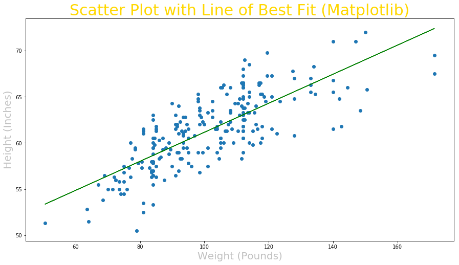

```python
# We saw an example with seaborn of how to plot the line of best fit with regplot, but we can also plot the line with Matplotlib

# Simple predict function

def predict(x):
    return regResult.slope * x + regResult.intercept

# Building the plot

plt.figure(figsize=(15,8))
plt.title("Scatter Plot with Line of Best Fit (Matplotlib)", size="30", color="gold")
plt.xlabel("Weight (Pounds)", size="20", color="silver")
plt.ylabel("Height (Inches)", size="20", color="silver")
# Original Scatterplot
plt.scatter(df.WeightLB, df.HeightIn)
# Regression Line
plt.plot(df['WeightLB'], predict(df['WeightLB']), 'g-')
plt.show()
```

## Future Workshop Topics

First of all, thank you so much for attending and completing the hands-on workshop. Here are some examples of future workshops that can really excite you to join the DevMasters Bootcamp and that come in a sequence after finishing this workshop.

1. Multiple Linear Regression in Scikit-Learn to Predict KC County House Prices
2. Build a Decision Tree to Decide Who Gets Approved for a Loan
3. Getting Hands-On with Principle Components Analysis
4. Sentiment Analysis with Tweets

## Join a DevMasters Program

The DevMasters program is ranked in the top 10 Data Science bootcamps on Switchup. In the DevMaster's comprehensive programs, you'll learn data science skills to the point of being truly job-ready with an optimized portfolio of projects to impress your employers.

### Mastering Applied Data Science

Mastering Applied Data Science is a project-driven course that will teach students the practical aspects of data science, such as collecting data by web scrapping, validation of information in data by data analysis, comparing models created by machine learning algorithms by interpreted metrics, and more. Additionally, we dive into the more enhanced aspects of data science by introducing topics, such as recommender systems, natural language processing, deep learning, and computer vision, which are all up-and-coming highlights in everyday applications of artificial intelligence. Our classes provide background and insights while solidifying the ideals through hands-on in-class projects and full take-home projects, where students are expected to present their findings and documentations on their journey throughout their project and explain further on what would be their next step.

Content from: https://www.thedevmasters.com/mastering-applied-data-science

```python
display(IFrame(src="https://www.thedevmasters.com/mastering-applied-data-science", height=500, width=800))
```

[interactive chart not shown]

If you want to build your skills in a particular area of machine learning such as deep learning, there is a new Deep Learning program designed to get a hands-on and strong grounding in Deep Learning and Neural Networks.